# Twitter API

Tom Theile

July 2022

# Accessing the Twitter API

This tutorial is vaguely based on this official tutorial from Twitter: https://developer.twitter.com/en/docs/tutorials/getting-started-with-r-and-v2-of-the-twitter-api

### Getting access

With every request to the Twitter API you have to send a personal access key, the API-token, to Twitter. This token is unique for every API-user and identifies you to Twitter. Twitter can then validate that you are indeed allowed to make this request. An access token looks vaguely like this: “1163470362377224163-jagGWNalfOtV78aRwCauSMl8Ln6blc”

Please follow the instructions from Twitter on how to get access to the API: https://developer.twitter.com/en/docs/twitter-api/getting-started/getting-access-to-the-twitter-api

The basic steps are:

1. Sign up for Twitter https://twitter.com/
2. Sign up for a developer account https://developer.twitter.com/en
3. Create an “App” here: https://developer.twitter.com/en/portal/projects-and-apps
4. Generate acces-token and bearer-token in the “keys” section of your Twitter project dashboard https://developer.twitter.com/en/portal/dashboard (create a project and then click on the key-symbol)

Store the tokens in a text file. You can store it in your code if you do not redistribute the code. You can invalidate and regenerate the tokens, if you “loose” them.

```r
# create headers for your request:
headers <- c(`Authorization` = sprintf('Bearer %s', bearer_token))
headers
```

```
##                                                                                                             Authorization
## "Bearer AAAAAAAAAAAAAAAAAAAAAJkCCQEAAAAAyY09uv5kiLlDGYHMn2ADdWWXVNY%3DMQAhsYccKDpxmq2VCFmtMxcnFMOiSBqfsMkXRkxD5m7IbIkqwK"
```

Headers can be send with every request to the server. A http-header can contain some variables. Twitter expects a key value pair like `"Authorization":{"Bearer":"...your bearer token..."}` to authenticate your query. Twitter will check whether the account with that token has access to the API with this token.

Now you are ready to format your URL with the Twitter handle, also known as account, you are looking to get more information about.

```r
username <- "ezagheni"
url1 <-  sprintf('https://api.twitter.com/2/users/by?usernames=%s', username) # sprintf is a way to concatenate strings. `%s` will be replaced by the content of `handle`
```

At this point, use the httr package to make a GET request to the URL you just created, pass in our authentication credential via the header, and pass in the parameters you defined. You can save the response as a text object in the variable obj and print this out to view the result of the request you made.

```r
response <- httr::GET(url = url1, httr::add_headers(.headers = headers))
obj <- httr::content(response, as = "text")
print(obj)
```

```
## [1] "{\"data\":[{\"id\":\"280994911\",\"name\":\"Emilio Zagheni\",\"username\":\"ezagheni\"}]}"
```

We can use the fromJSON function of the package jsonlite to convert the text with the json-response into something more readable:

```r
fromJSON(obj)
```

```
## $data
##          id           name username
## 1 280994911 Emilio Zagheni ezagheni
```

Well, let’s try to get more information from this user. By default, only the above information is returned. We can look into the documentation on how to get more information: https://developer.twitter.com/en/docs/twitter-api/users/lookup/quick-start/user-lookup

```r
username <- "ezagheni"
url1 <-  sprintf('https://api.twitter.com/2/users/by?usernames=%s&user.fields=created_at&expansions=pinned_tweet_id&tweet.fields=author_id,created_at', username)


response <- httr::GET(url = url1, httr::add_headers(.headers = headers))
obj <- httr::content(response, as = "text")
print(obj)
```

```
## [1] "{\"data\":[{\"username\":\"ezagheni\",\"created_at\":\"2011-04-12T12:28:15.000Z\",\"name\":\"Emilio Zagheni\",\"id\":\"280994911\"}]}"
```

```r
fromJSON(obj)
```

```
## $data
##   username               created_at           name        id
## 1 ezagheni 2011-04-12T12:28:15.000Z Emilio Zagheni 280994911
```

Wow, since 2011! Let’s use his userID to look up his followers:

```r
obj <- httr::content(response, as = "parsed")
userid <- obj$data[[1]]$id
url1 <-  sprintf('https://api.twitter.com/2/users/%s/followers?user.fields=created_at&expansions=pinned_tweet_id&tweet.fields=created_at', userid)


response <- httr::GET(url = url1, httr::add_headers(.headers = headers))
obj <- httr::content(response, as = "text")
print(obj)
```

```
## [1] "{\"data\":[{\"created_at\":\"2011-03-20T15:54:39.000Z\",\"id\":\"269346138\",\"pinned_tweet_id\":\"1376271749696737283\",\"username\":\"SalomonJA\",\"name\":\"Joshua Salomon\"},{\"created_at\":\"2012-03-05T18:49:26.000Z\",\"id\":\"515748473\",\"username\":\"sdshwetadixit\",\"name\":\"shweta …
```

```r
fromJSON(obj)
```

```
## $data
##                   created_at                  id     pinned_tweet_id
## 1   2011-03-20T15:54:39.000Z           269346138 1376271749696737283
## 2   2012-03-05T18:49:26.000Z           515748473                <NA>
## 3   2022-06-23T18:00:26.000Z 1540031987481804802                <NA>
## 4   2017-05-09T14:19:17.000Z  861948693129383937                <NA>
## 5   2015-04-05T21:22:52.000Z          3138543718                <NA>
## 6   2022-01-01T22:22:57.000Z 1477404943237668867                <NA>
## 7   2021-05-02T14:42:23.000Z 1388866150419869697                <NA>
## 8   2010-10-01T08:05:22.000Z           197351567                <NA>
## 9   2022-07-05T23:23:40.000Z 1544461997277839365                <NA>
## 10  2020-05-13T15:52:36.000Z 1260598788843909120                <NA>
## 11  2021-09-03T11:12:43.000Z 1433749542604791815 1547186107405795328
## 12  2018-01-19T12:50:06.000Z  954335153723183104                <NA>
## 13  2012-06-27T10:21:28.000Z           619871911                <NA>
```

[output cut: 364 more lines]

```r
print("no")
```

```
## [1] "no"
```

Cool, 100 followers with their usernames and created_at dates. But why only 100? The answer is divided into pages and to get the next 100 pages, we have to use the nex_page_token in the answer.

To pull the next page of results, you will pull the value of the next_token field, and add it to the request as the value to an additional pagination_token parameter.

```r
obj <- httr::content(response, as = "parsed")
next_token <- obj$meta$next_token # get the token for the next page

# and then do the same thing as above, but with a next_token added:
url1 <-  sprintf('https://api.twitter.com/2/users/%s/followers?user.fields=created_at&expansions=pinned_tweet_id&tweet.fields=created_at&pagination_token=%s&max_results=800', userid,next_token)
response <- httr::GET(url = url1, httr::add_headers(.headers = headers))
obj <- httr::content(response, as = "text")
print(obj)
```

```
## [1] "{\"data\":[{\"pinned_tweet_id\":\"1443556499758923783\",\"username\":\"Mosquito_Alert\",\"id\":\"1560072704\",\"created_at\":\"2013-07-01T09:06:30.000Z\",\"name\":\"Mosquito Alert\"},{\"pinned_tweet_id\":\"1509824980015788041\",\"username\":\"dilettagoglia\",\"id\":\"1047160761661972482\",\"…
```

```r
#fromJSON(obj)
```

**Exercise 3.1:** Look up how to retrieve 800 followers at once, not 100

## Getting Tweet counts from the last 7 days

Documentation for getting tweet counts can be found here: https://developer.twitter.com/en/docs/twitter-api/tweets/counts/introduction

The normal access-level can only retrieve Data for the last 7 days. The Academic Access level can retrieve counts from the full history of Twitter. But only for 30 days in one request.

The following example works with the low-access API:

```r
url_handle <- "https://api.twitter.com/2/tweets/counts/recent?query=heatwave&granularity=day"

response <- httr::GET(url = url_handle, httr::add_headers(.headers = headers))
response
```

```
## Response [https://api.twitter.com/2/tweets/counts/recent?query=heatwave&granularity=day]
##   Date: 2022-07-21 08:09
##   Status: 200
##   Content-Type: application/json; charset=utf-8
##   Size: 771 B
```

```r
obj <- httr::content(response, as = "text")
print(obj)
```

```
## [1] "{\"data\":[{\"end\":\"2022-07-15T00:00:00.000Z\",\"start\":\"2022-07-14T08:09:02.000Z\",\"tweet_count\":29231},{\"end\":\"2022-07-16T00:00:00.000Z\",\"start\":\"2022-07-15T00:00:00.000Z\",\"tweet_count\":66640},{\"end\":\"2022-07-17T00:00:00.000Z\",\"start\":\"2022-07-16T00:00:00.000Z\",\"tw…
```

```r
print(fromJSON(obj))
```

```
## $data
##                        end                    start tweet_count
## 1 2022-07-15T00:00:00.000Z 2022-07-14T08:09:02.000Z       29231
## 2 2022-07-16T00:00:00.000Z 2022-07-15T00:00:00.000Z       66640
## 3 2022-07-17T00:00:00.000Z 2022-07-16T00:00:00.000Z      114443
## 4 2022-07-18T00:00:00.000Z 2022-07-17T00:00:00.000Z      121844
## 5 2022-07-19T00:00:00.000Z 2022-07-18T00:00:00.000Z      192472
## 6 2022-07-20T00:00:00.000Z 2022-07-19T00:00:00.000Z      231705
## 7 2022-07-21T00:00:00.000Z 2022-07-20T00:00:00.000Z      139376
## 8 2022-07-21T08:09:02.000Z 2022-07-21T00:00:00.000Z       19362
##
## $meta
## $meta$total_tweet_count
## [1] 915073
```

Let’s make a small plot:

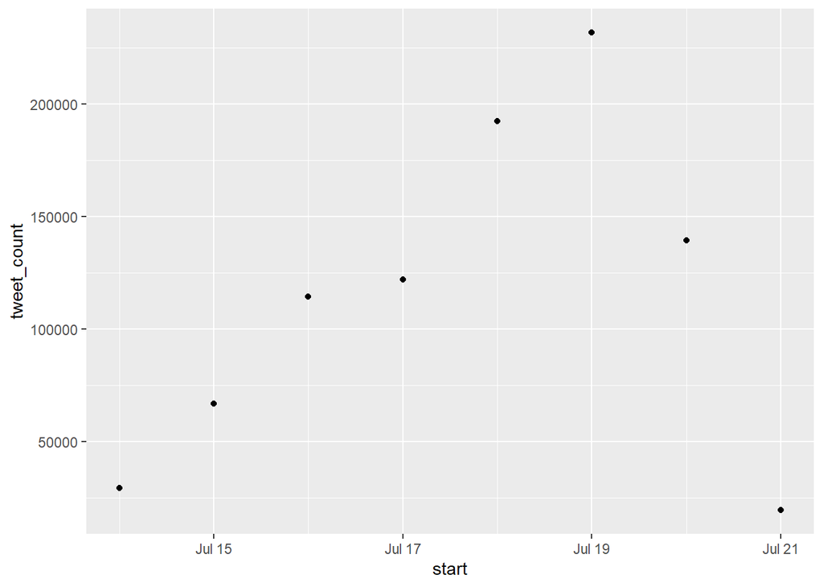

```r
dfresponse = fromJSON(obj)[[1]]
dfresponse$start = as.Date(dfresponse$start)
ggplot(dfresponse, aes(x=start, y=tweet_count)) +
  geom_point()
```

A query can be be crafted to target very specific stuff only. The simplest query, which we used above, only looks for one specific keyword `query=heatwave`.

Another simple query would be look for a specific username: `query=from:BarackObama`

```r
url_handle <- "https://api.twitter.com/2/tweets/counts/recent?query=from:MPIDRnews&granularity=day"
url_handle <- "https://api.twitter.com/2/tweets/counts/recent?query=from:POTUS&granularity=day"
response <-  GET(url = url_handle, httr::add_headers(.headers = headers))
obj <- httr::content(response, as = "text")
print(fromJSON(obj))
```

```
## $data
##                        end                    start tweet_count
## 1 2022-07-15T00:00:00.000Z 2022-07-14T08:09:04.000Z           5
## 2 2022-07-16T00:00:00.000Z 2022-07-15T00:00:00.000Z           6
## 3 2022-07-17T00:00:00.000Z 2022-07-16T00:00:00.000Z           4
## 4 2022-07-18T00:00:00.000Z 2022-07-17T00:00:00.000Z           5
## 5 2022-07-19T00:00:00.000Z 2022-07-18T00:00:00.000Z           2
## 6 2022-07-20T00:00:00.000Z 2022-07-19T00:00:00.000Z           7
## 7 2022-07-21T00:00:00.000Z 2022-07-20T00:00:00.000Z           9
## 8 2022-07-21T08:09:04.000Z 2022-07-21T00:00:00.000Z           1
##
## $meta
## $meta$total_tweet_count
## [1] 39
```

```r
query = URLencode("has:geo explosion place_country:UA")
url_handle <- sprintf("https://api.twitter.com/2/tweets/counts/recent?query=%s&granularity=day",query)
print(url_handle)
```

```
## [1] "https://api.twitter.com/2/tweets/counts/recent?query=has:geo%20explosion%20place_country:UA&granularity=day"
```

```r
response <-  httr::GET(url = url_handle, httr::add_headers(.headers = headers))
obj <- httr::content(response, as = "text")
print(fromJSON(obj))
```

```
## $data
##                        end                    start tweet_count
## 1 2022-07-15T00:00:00.000Z 2022-07-14T08:09:04.000Z           6
## 2 2022-07-16T00:00:00.000Z 2022-07-15T00:00:00.000Z           5
## 3 2022-07-17T00:00:00.000Z 2022-07-16T00:00:00.000Z           2
## 4 2022-07-18T00:00:00.000Z 2022-07-17T00:00:00.000Z           0
## 5 2022-07-19T00:00:00.000Z 2022-07-18T00:00:00.000Z           0
## 6 2022-07-20T00:00:00.000Z 2022-07-19T00:00:00.000Z           0
## 7 2022-07-21T00:00:00.000Z 2022-07-20T00:00:00.000Z           2
## 8 2022-07-21T08:09:04.000Z 2022-07-21T00:00:00.000Z           0
##
## $meta
## $meta$total_tweet_count
## [1] 15
```

```r
query = URLencode('"computational demography"') # or is "digital demography" more common?
url_handle <- sprintf("https://api.twitter.com/2/tweets/counts/recent?query=%s&granularity=day",query)
print(url_handle)
```

```
## [1] "https://api.twitter.com/2/tweets/counts/recent?query=%22computational%20demography%22&granularity=day"
```

```r
response <-  httr::GET(url = url_handle, httr::add_headers(.headers = headers))
obj <- httr::content(response, as = "text")
print(fromJSON(obj))
```

```
## $data
##                        end                    start tweet_count
## 1 2022-07-15T00:00:00.000Z 2022-07-14T08:09:05.000Z           0
## 2 2022-07-16T00:00:00.000Z 2022-07-15T00:00:00.000Z           0
## 3 2022-07-17T00:00:00.000Z 2022-07-16T00:00:00.000Z           0
## 4 2022-07-18T00:00:00.000Z 2022-07-17T00:00:00.000Z           0
## 5 2022-07-19T00:00:00.000Z 2022-07-18T00:00:00.000Z           0
## 6 2022-07-20T00:00:00.000Z 2022-07-19T00:00:00.000Z           0
## 7 2022-07-21T00:00:00.000Z 2022-07-20T00:00:00.000Z           0
## 8 2022-07-21T08:09:05.000Z 2022-07-21T00:00:00.000Z           0
##
## $meta
## $meta$total_tweet_count
## [1] 0
```

```r
query = URLencode('place:"Germany"') # Tweets
url_handle <- sprintf("https://api.twitter.com/2/tweets/counts/recent?query=%s&granularity=day",query)
print(url_handle)
```

```
## [1] "https://api.twitter.com/2/tweets/counts/recent?query=place:%22Germany%22&granularity=day"
```

```r
response <-  httr::GET(url = url_handle, httr::add_headers(.headers = headers))
obj <- httr::content(response, as = "text")
print(fromJSON(obj))
```

```
## $data
##                        end                    start tweet_count
## 1 2022-07-15T00:00:00.000Z 2022-07-14T08:09:05.000Z        3226
## 2 2022-07-16T00:00:00.000Z 2022-07-15T00:00:00.000Z        3877
## 3 2022-07-17T00:00:00.000Z 2022-07-16T00:00:00.000Z        3991
## 4 2022-07-18T00:00:00.000Z 2022-07-17T00:00:00.000Z        4457
## 5 2022-07-19T00:00:00.000Z 2022-07-18T00:00:00.000Z        4539
## 6 2022-07-20T00:00:00.000Z 2022-07-19T00:00:00.000Z        4549
## 7 2022-07-21T00:00:00.000Z 2022-07-20T00:00:00.000Z        5020
## 8 2022-07-21T08:09:05.000Z 2022-07-21T00:00:00.000Z         899
##
## $meta
## $meta$total_tweet_count
## [1] 30558
```

```r
query = URLencode('place_country:DE') # Tweets
url_handle <- sprintf("https://api.twitter.com/2/tweets/counts/recent?query=%s&granularity=day",query)
print(url_handle)
```

```
## [1] "https://api.twitter.com/2/tweets/counts/recent?query=place_country:DE&granularity=day"
```

```r
response <-  httr::GET(url = url_handle, httr::add_headers(.headers = headers))
obj <- httr::content(response, as = "text")
print(fromJSON(obj))
```

```
## $data
##                        end                    start tweet_count
## 1 2022-07-15T00:00:00.000Z 2022-07-14T08:09:05.000Z       17780
## 2 2022-07-16T00:00:00.000Z 2022-07-15T00:00:00.000Z       23780
## 3 2022-07-17T00:00:00.000Z 2022-07-16T00:00:00.000Z       24591
## 4 2022-07-18T00:00:00.000Z 2022-07-17T00:00:00.000Z       25443
## 5 2022-07-19T00:00:00.000Z 2022-07-18T00:00:00.000Z       26540
## 6 2022-07-20T00:00:00.000Z 2022-07-19T00:00:00.000Z       28110
## 7 2022-07-21T00:00:00.000Z 2022-07-20T00:00:00.000Z       29197
## 8 2022-07-21T08:09:05.000Z 2022-07-21T00:00:00.000Z        6384
##
## $meta
## $meta$total_tweet_count
## [1] 181825
```

```r
query = URLencode('place:"Deutschland"') # Tweets
url_handle <- sprintf("https://api.twitter.com/2/tweets/counts/recent?query=%s&granularity=day",query)
print(url_handle)
```

```
## [1] "https://api.twitter.com/2/tweets/counts/recent?query=place:%22Deutschland%22&granularity=day"
```

```r
response <-  httr::GET(url = url_handle, httr::add_headers(.headers = headers))
obj <- httr::content(response, as = "text")
print(fromJSON(obj))
```

```
## $data
##                        end                    start tweet_count
## 1 2022-07-15T00:00:00.000Z 2022-07-14T08:09:06.000Z       13451
## 2 2022-07-16T00:00:00.000Z 2022-07-15T00:00:00.000Z       18387
## 3 2022-07-17T00:00:00.000Z 2022-07-16T00:00:00.000Z       19005
## 4 2022-07-18T00:00:00.000Z 2022-07-17T00:00:00.000Z       19285
## 5 2022-07-19T00:00:00.000Z 2022-07-18T00:00:00.000Z       20419
## 6 2022-07-20T00:00:00.000Z 2022-07-19T00:00:00.000Z       21770
## 7 2022-07-21T00:00:00.000Z 2022-07-20T00:00:00.000Z       22527
## 8 2022-07-21T08:09:06.000Z 2022-07-21T00:00:00.000Z        5198
##
## $meta
## $meta$total_tweet_count
## [1] 140042
```

You can find much more information about building queries here: https://developer.twitter.com/en/docs/twitter-api/tweets/counts/integrate/build-a-query

#### Full archive search

This is only possible with the academic-access as you can read here: https://developer.twitter.com/en/docs/twitter-api/tweets/counts/api-reference/get-tweets-counts-all the differences to the “recent-counts” API are not big: * replace `recent` with `all` * This will give us the last 30 days of a query by default * optionally we can define an end_time and start_time to request a specific time frame * if there are too many entries (days/hours/minutes), the answer will be paged

```r
query = URLencode('heatwave') #
url_handle <- sprintf("https://api.twitter.com/2/tweets/counts/all?query=%s&granularity=day",query)
print(url_handle)
```

```
## [1] "https://api.twitter.com/2/tweets/counts/all?query=heatwave&granularity=day"
```

```r
response <-  httr::GET(url = url_handle, httr::add_headers(.headers = headers))
obj <- httr::content(response, as = "text")
print(fromJSON(obj))
```

```
## $data
##                         end                    start tweet_count
## 1  2022-06-22T00:00:00.000Z 2022-06-21T00:00:00.000Z        6151
## 2  2022-06-23T00:00:00.000Z 2022-06-22T00:00:00.000Z        5832
## 3  2022-06-24T00:00:00.000Z 2022-06-23T00:00:00.000Z        5897
## 4  2022-06-25T00:00:00.000Z 2022-06-24T00:00:00.000Z        4317
## 5  2022-06-26T00:00:00.000Z 2022-06-25T00:00:00.000Z        4086
## 6  2022-06-27T00:00:00.000Z 2022-06-26T00:00:00.000Z        3453
## 7  2022-06-28T00:00:00.000Z 2022-06-27T00:00:00.000Z        4864
## 8  2022-06-29T00:00:00.000Z 2022-06-28T00:00:00.000Z        5399
## 9  2022-06-30T00:00:00.000Z 2022-06-29T00:00:00.000Z        6423
## 10 2022-07-01T00:00:00.000Z 2022-06-30T00:00:00.000Z        7526
## 11 2022-07-02T00:00:00.000Z 2022-07-01T00:00:00.000Z        5366
## 12 2022-07-03T00:00:00.000Z 2022-07-02T00:00:00.000Z        3554
## 13 2022-07-04T00:00:00.000Z 2022-07-03T00:00:00.000Z        3253
```

[output cut: 22 more lines]

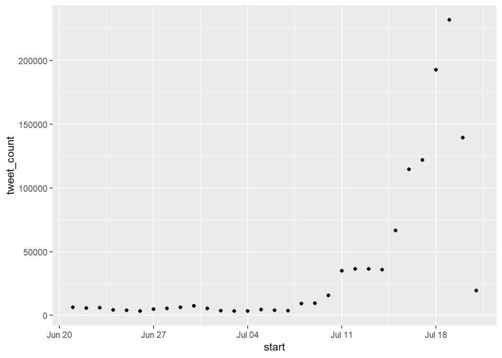

```r
dfresponse = fromJSON(obj)[[1]]
dfresponse$start = as.Date(dfresponse$start)
ggplot(dfresponse, aes(x=start, y=tweet_count)) +
  geom_point()
```

```r
query = URLencode('heat spain') #
url_handle <- sprintf("https://api.twitter.com/2/tweets/counts/all?query=%s&granularity=day",query)
print(url_handle)
```

```
## [1] "https://api.twitter.com/2/tweets/counts/all?query=heat%20spain&granularity=day"
```

```r
response <-  httr::GET(url = url_handle, httr::add_headers(.headers = headers))
obj <- httr::content(response, as = "text")
print(fromJSON(obj))
```

```
## $data
##                         end                    start tweet_count
## 1  2022-06-22T00:00:00.000Z 2022-06-21T00:00:00.000Z         277
## 2  2022-06-23T00:00:00.000Z 2022-06-22T00:00:00.000Z         348
## 3  2022-06-24T00:00:00.000Z 2022-06-23T00:00:00.000Z         103
## 4  2022-06-25T00:00:00.000Z 2022-06-24T00:00:00.000Z          87
## 5  2022-06-26T00:00:00.000Z 2022-06-25T00:00:00.000Z          64
## 6  2022-06-27T00:00:00.000Z 2022-06-26T00:00:00.000Z         132
## 7  2022-06-28T00:00:00.000Z 2022-06-27T00:00:00.000Z         135
## 8  2022-06-29T00:00:00.000Z 2022-06-28T00:00:00.000Z          89
## 9  2022-06-30T00:00:00.000Z 2022-06-29T00:00:00.000Z         148
## 10 2022-07-01T00:00:00.000Z 2022-06-30T00:00:00.000Z         198
## 11 2022-07-02T00:00:00.000Z 2022-07-01T00:00:00.000Z          95
## 12 2022-07-03T00:00:00.000Z 2022-07-02T00:00:00.000Z         106
## 13 2022-07-04T00:00:00.000Z 2022-07-03T00:00:00.000Z          95
```

[output cut: 22 more lines]

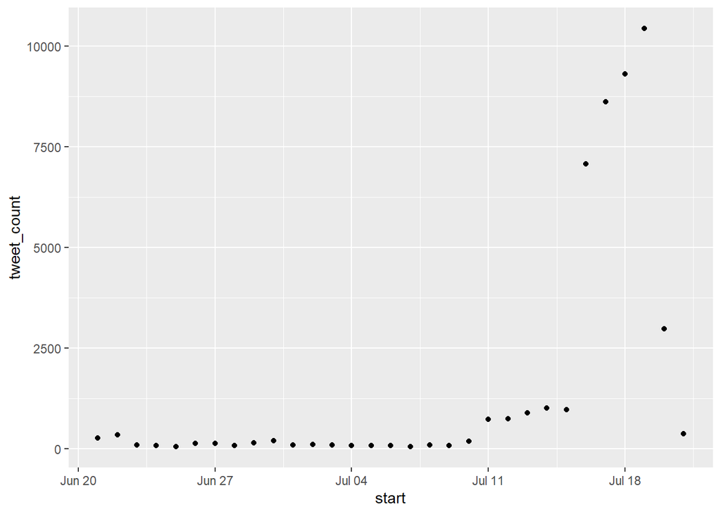

```r
dfresponse = fromJSON(obj)[[1]]
dfresponse$start = as.Date(dfresponse$start)
ggplot(dfresponse, aes(x=start, y=tweet_count)) +
  geom_point()
```

**Exercise 3.2:** How many tweets are there in the last 30 days:

- from the Ukraine, with images
- from Germany with the keyword “fire”
- with a link to demogr.mpg.de or your institutes website?
- Are there more English or more German tweets with a place:“Berlin”?

(pick one task, use the official documentation)

## Retrieving Tweets

### By Search

https://developer.twitter.com/en/docs/twitter-api/tweets/search/quick-start/recent-search

The query can be the same as in the tweet-counts-API. But we can add some parameters that tell the API what exactly it should send back to us. Twitter not only saves the 280 characters of a tweet, but a lot of other data which is not included by default.

```r
query = URLencode('machine learning vulnerability') # or ...
fulltext = URLencode("tweet_mode='extended'")
url_handle <- sprintf("https://api.twitter.com/2/tweets/search/recent?query=%s&tweet.fields=created_at&expansions=author_id,geo.place_id&user.fields=created_at",query)
print(url_handle)
```

```
## [1] "https://api.twitter.com/2/tweets/search/recent?query=machine%20learning%20vulnerability&tweet.fields=created_at&expansions=author_id,geo.place_id&user.fields=created_at"
```

```r
response <-  httr::GET(url = url_handle, httr::add_headers(.headers = headers))
obj <- httr::content(response, as = "text")
obj
```

```
## [1] "{\"data\":[{\"id\":\"1549845254093713408\",\"author_id\":\"1080825624246157313\",\"text\":\"RT @eitatli: 4)Ubuntu One Investigation: Detecting Evidences on Client Machines https://t.co/tEQpU361H5\\n\\n5) A Survey of Machine and Deep Le…\",\"created_at\":\"2022-07-20T19:54:37.000Z\"},{\"id\":…
```

```r
print(fromJSON(obj))
```

```
## $data
##                    id           author_id
## 1 1549845254093713408 1080825624246157313
## 2 1549813680094777345          2343273908
## 3 1549675612993896449          2644616076
## 4 1549376550562398209  983658091874054144
## 5 1549375996851363840  723157244653658112
## 6 1547903730221060098            14845783
## 7 1547862508039700482 1506806837831938050
## 8 1547579514695213057           410212969
## 9 1547506932965154820           418918822
##                                                                                                                                                                                                                                                                                    text
## 1                                                                                                                                        RT @eitatli: 4)Ubuntu One Investigation: Detecting Evidences on Client Machines https://t.co/tEQpU361H5\n\n5) A Survey of Machine and Deep Le…
## 2                                                                                                                        #Physics - Security - Get a better understanding of physics by vulnerability testing on a physics engine. Patch with machine learning then repeat search //Per
## 3                                                                                             Discussion open for comments: Using machine learning algorithms to identify predictors of social vulnerability in the event of an earthquake: Istanbul case study https://t.co/k89B9UChia
```

[output cut: 50 more lines]

```r
dfresponse = fromJSON(obj)[[1]]
dfresponse
```

```
##                    id           author_id
## 1 1549845254093713408 1080825624246157313
## 2 1549813680094777345          2343273908
## 3 1549675612993896449          2644616076
## 4 1549376550562398209  983658091874054144
## 5 1549375996851363840  723157244653658112
## 6 1547903730221060098            14845783
## 7 1547862508039700482 1506806837831938050
## 8 1547579514695213057           410212969
## 9 1547506932965154820           418918822
##                                                                                                                                                                                                                                                                                    text
## 1                                                                                                                                        RT @eitatli: 4)Ubuntu One Investigation: Detecting Evidences on Client Machines https://t.co/tEQpU361H5\n\n5) A Survey of Machine and Deep Le…
## 2                                                                                                                        #Physics - Security - Get a better understanding of physics by vulnerability testing on a physics engine. Patch with machine learning then repeat search //Per
## 3                                                                                             Discussion open for comments: Using machine learning algorithms to identify predictors of social vulnerability in the event of an earthquake: Istanbul case study https://t.co/k89B9UChia
## 4                                                                                                                                          RT @PSUPublicHealth: New #PennState #research by @KristinSznajder:  #Suicide vulnerability index, machine learning model help predict count…
## 5                                                                          New #PennState #research by @KristinSznajder:  #Suicide vulnerability index, machine learning model help predict counties’ risk\n\nhttps://t.co/P6DapwR0Ta\n\n#PublicHealth #MentalHealth #SuicidePrevention
## 6 @immuniweb Neuron’s vulnerability fuzzing engine is enhanced with a set of interconnected machine learning models, trained on real penetration testing data. It intelligently automates complicated tasks, spanning from business logic testing to WAF bypass https://t.co/xx8CjSIYsK
## 7                                                                                                                                          RT @LG_Cyber: Threat actors exploiting #Log4j have created a dangerous game of Tetris for countless orgs involved in the software component…
## 8                                                                                                                                          RT @PSUresearch: Penn State researchers have developed a machine learning-based model that uses a suicide-vulnerability index to identify a…
## 9                                                                                                                                          RT @LG_Cyber: Threat actors exploiting #Log4j have created a dangerous game of Tetris for countless orgs involved in the software component…
##                 created_at
## 1 2022-07-20T19:54:37.000Z
## 2 2022-07-20T17:49:10.000Z
## 3 2022-07-20T08:40:32.000Z
## 4 2022-07-19T12:52:10.000Z
## 5 2022-07-19T12:49:58.000Z
## 6 2022-07-15T11:19:42.000Z
## 7 2022-07-15T08:35:54.000Z
## 8 2022-07-14T13:51:23.000Z
## 9 2022-07-14T09:02:58.000Z
```

```r
#jresponse <-fromJSON(obj)
#jresponse$data[1]$text
```

**Exercise 3.3:** Play around with the query and search for more interesting tweets. Use the geo-tags, exclude a word by adding a minus sign: -demography

Find an interesting API-Endpoint here: https://developer.twitter.com/en/docs/api-reference-index